# Multiple Linear Regression & Diagnostics

Mariam Walaa

```r
library(car)
library(MASS)
library(corrplot)
library(tidyverse)
```

### Data

This data set comes from the UCI Machine Learning Repository and can be found [here](https://archive.ics.uci.edu/ml/datasets/Facebook+metrics). According to the data abstract, this data set consists of posts published during the year of 2014 on the Facebook pages of a renowned cosmetics brand. The data set contains 500 rows and 19 variables about each post. The dependent variable is the number of people who clicked on the post.

```r
facebook <- read.csv(file = '../data/Facebook_metrics/dataset_Facebook.csv', sep = ';')
```

```r
facebook <-
  facebook %>%
  na.omit()
```

## Dataset Correlations

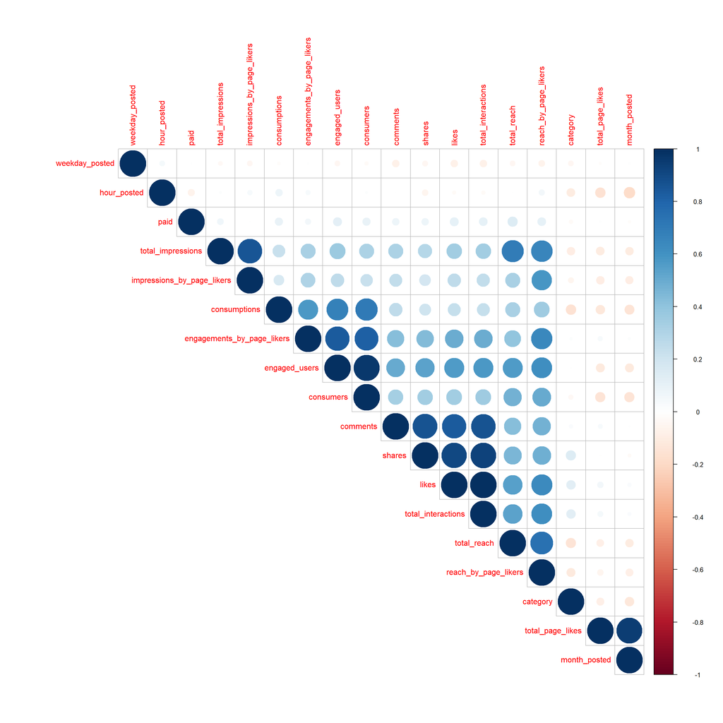

```r
facebook %>%
  select(!type) %>%
  cor() %>%
  corrplot(type = "upper",
           order = "hclust")
```

## Model Selection

```r
stepAIC(lm(consumers ~
             category +
             total_page_likes +
             type +
             month_posted +
             hour_posted +
             weekday_posted +
             paid,
           data = facebook),
        trace = FALSE)$anova
```

```
## Stepwise Model Path
## Analysis of Deviance Table
##
## Initial Model:
## consumers ~ category + total_page_likes + type + month_posted +
##     hour_posted + weekday_posted + paid
##
## Final Model:
## consumers ~ category + total_page_likes + type + weekday_posted +
##     paid
##
##
##             Step Df Deviance Resid. Df Resid. Dev      AIC
## 1                                  485  280057809 6576.745
## 2  - hour_posted  1 320736.4       486  280378545 6575.311
## 3 - month_posted  1 316715.5       487  280695261 6573.870
```

```r
lm(consumers ~
     category +
     total_page_likes +
     type +
     weekday_posted +
     paid,
   data = facebook) %>%
  summary()
```

```
##
## Call:
## lm(formula = consumers ~ category + total_page_likes + type +
##     weekday_posted + paid, data = facebook)
##
## Residuals:
##     Min      1Q  Median      3Q     Max
## -2065.5  -279.6  -112.1   137.0  9945.6
##
## Coefficients:
##                    Estimate Std. Error t value Pr(>|t|)
## (Intercept)       2.150e+03  3.190e+02   6.738 4.55e-11 ***
## category         -9.581e+01  4.144e+01  -2.312  0.02118 *
## total_page_likes -1.457e-02  2.174e-03  -6.700 5.76e-11 ***
## typePhoto         5.585e+02  1.700e+02   3.286  0.00109 **
## typeStatus        1.997e+03  2.048e+02   9.751  < 2e-16 ***
## typeVideo         1.472e+03  3.329e+02   4.421 1.21e-05 ***
## weekday_posted   -2.551e+01  1.690e+01  -1.510  0.13177
## paid              2.048e+02  7.623e+01   2.686  0.00748 **
## ---
## Signif. codes:  0 '***' 0.001 '**' 0.01 '*' 0.05 '.' 0.1 ' ' 1
##
## Residual standard error: 759.2 on 487 degrees of freedom
## Multiple R-squared:  0.2748, Adjusted R-squared:  0.2644
## F-statistic: 26.37 on 7 and 487 DF,  p-value: < 2.2e-16
```

## Variable Correlations

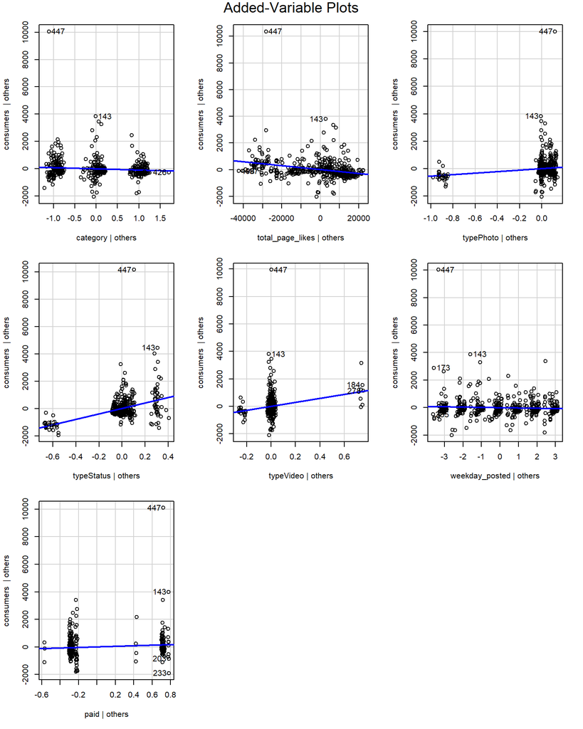

```r
lm(consumers ~
     category +
     total_page_likes +
     type +
     weekday_posted +
     paid,
   data = facebook) %>%
  avPlots()
```

The AV plots show that having a post of type Status or a post of type Video results in the most impact on the number of people clicking somewhere on the post, followed by total page likes.

```r
facebook %>%
  select(category,
         total_page_likes,
         weekday_posted,
         paid) %>%
  cor()
```

```
##                     category total_page_likes weekday_posted         paid
## category          1.00000000     -0.084925173   -0.045016411 -0.027817814
## total_page_likes -0.08492517      1.000000000   -0.012684630  0.009405895
## weekday_posted   -0.04501641     -0.012684630    1.000000000  0.003250011
## paid             -0.02781781      0.009405895    0.003250011  1.000000000
```

```r
lm(consumers ~
     category +
     total_page_likes +
     type +
     weekday_posted +
     paid,
   data = facebook) %>%
  vif()
```

```
##                      GVIF Df GVIF^(1/(2*Df))
## category         1.071384  1        1.035077
## total_page_likes 1.063418  1        1.031222
## type             1.130912  3        1.020716
## weekday_posted   1.009469  1        1.004723
## paid             1.007993  1        1.003988
```

There are very small correlations among the selected independent variables, and this is supported by VIF values near 1, so there is no concern around having multi-collinearity in this model.

## Linear Regression

```r
model <- lm(consumers ~
              category +
              total_page_likes +
              type +
              weekday_posted +
              paid,
            data = facebook)
```

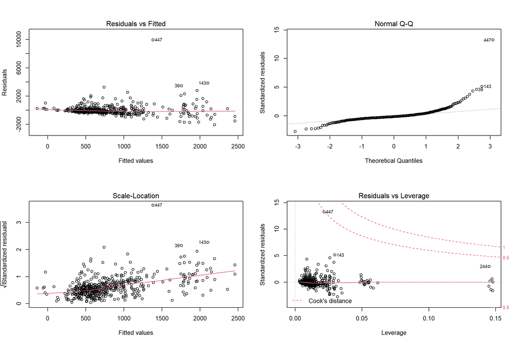

```r
par(mfrow = c(2,2))
plot(model)
```

The plot of fitted values against residuals shows an approximately horizontal line at zero with no clear pattern which supports linearity of the model. The normal QQ plot shows that the standardized residuals mostly lay along the dashed line but are skewed towards the beginning and end which may indicate that the residuals are not normally distributed. The scale-location plot shows that the standardized residuals do not have a constant variance as the line is not horizontal which may indicate heteroscedasticity. The residuals vs leverage plot shows that there are some points with a standardized residual greater than 3 which indicates the presence of outliers, as well as some extreme points including 447, 143, and 244 which may require further investigation.

```r
summary(model)
```

```
##
## Call:
## lm(formula = consumers ~ category + total_page_likes + type +
##     weekday_posted + paid, data = facebook)
##
## Residuals:
##     Min      1Q  Median      3Q     Max
## -2065.5  -279.6  -112.1   137.0  9945.6
##
## Coefficients:
##                    Estimate Std. Error t value Pr(>|t|)
## (Intercept)       2.150e+03  3.190e+02   6.738 4.55e-11 ***
## category         -9.581e+01  4.144e+01  -2.312  0.02118 *
## total_page_likes -1.457e-02  2.174e-03  -6.700 5.76e-11 ***
## typePhoto         5.585e+02  1.700e+02   3.286  0.00109 **
## typeStatus        1.997e+03  2.048e+02   9.751  < 2e-16 ***
## typeVideo         1.472e+03  3.329e+02   4.421 1.21e-05 ***
## weekday_posted   -2.551e+01  1.690e+01  -1.510  0.13177
## paid              2.048e+02  7.623e+01   2.686  0.00748 **
## ---
## Signif. codes:  0 '***' 0.001 '**' 0.01 '*' 0.05 '.' 0.1 ' ' 1
##
## Residual standard error: 759.2 on 487 degrees of freedom
## Multiple R-squared:  0.2748, Adjusted R-squared:  0.2644
## F-statistic: 26.37 on 7 and 487 DF,  p-value: < 2.2e-16
```

The distribution of the residuals does not appear to be normal. All of the independent variables in this model are statistically significant with exception to the variable representing the weekday posted. The model has a multiple R-squared of 0.2748 indicating that less than 30% of the variability in the data is explained by this model, and a p-value of < 2.2e-16 indicating the model is statistically significant.

## Linear Regression (transformed)

```r
facebook %>%
  select(consumers,
         category,
         total_page_likes,
         weekday_posted,
         paid) %>%
  powerTransform(family = 'yjPower')
```

```
## Estimated transformation parameters
##        consumers         category total_page_likes   weekday_posted
##        0.1039487       -0.1907310        5.4815911        0.8330330
##             paid
##       -4.3314030
```

The power transformations suggest that a power of 0.1 for the dependent variable will provide a more normal distribution. To make the model more interpretable, the log of consumers will be taken in the transformed model.

```r
transformed_model <- lm(log(consumers) ~
                          category +
                          total_page_likes +
                          type +
                          weekday_posted +
                          paid,
                        data = facebook)
```

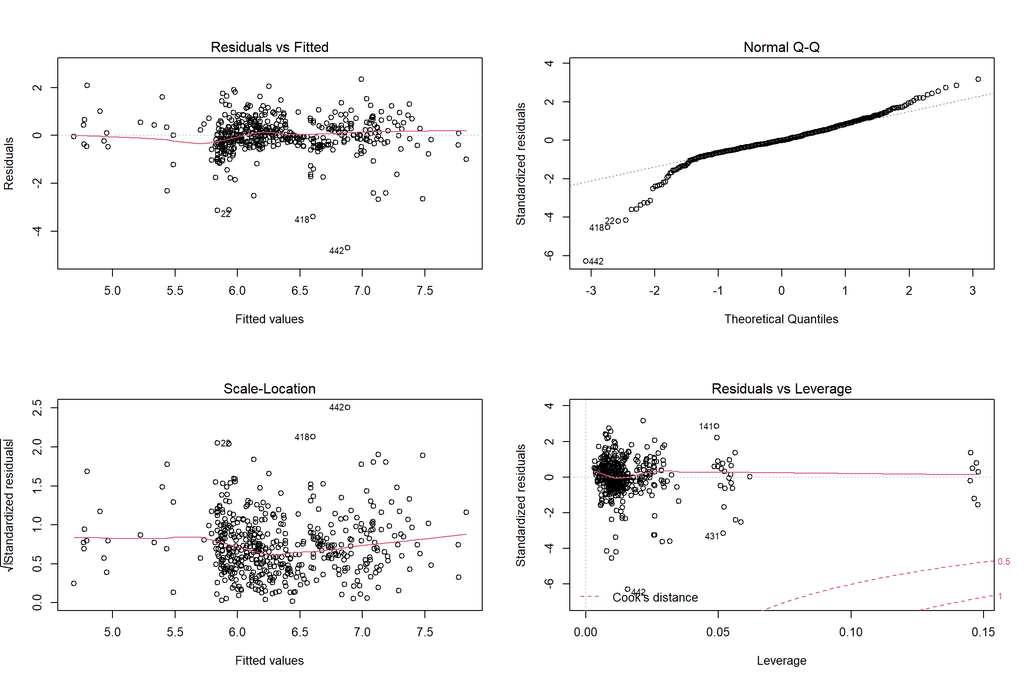

```r
par(mfrow = c(2,2))
plot(transformed_model)
```

The plot of fitted values against residuals shows no distinct pattern and slightly curved horizontal line. The normal QQ plot shows that most standardized residuals lie along the dashed line but are skewed towards the end and beginning which may indicate a non-normal distribution of residuals. The scale-location plot shows a slightly curved horizontal line which may indicate slightly non-constant variance in the residuals. The residuals vs leverage plot indicates very few points that have a standardized residual greater than 3 so there are likely few outliers, as well as some extreme values such as 431, 442, and 141.

```r
summary(transformed_model)
```

```
##
## Call:
## lm(formula = log(consumers) ~ category + total_page_likes + type +
##     weekday_posted + paid, data = facebook)
##
## Residuals:
##     Min      1Q  Median      3Q     Max
## -4.6831 -0.3268 -0.0093  0.3986  2.3436
##
## Coefficients:
##                    Estimate Std. Error t value Pr(>|t|)
## (Intercept)       7.605e+00  3.152e-01  24.129  < 2e-16 ***
## category         -2.253e-02  4.094e-02  -0.550  0.58224
## total_page_likes -1.987e-05  2.148e-06  -9.250  < 2e-16 ***
## typePhoto         1.150e+00  1.679e-01   6.851 2.22e-11 ***
## typeStatus        2.378e+00  2.023e-01  11.754  < 2e-16 ***
## typeVideo         2.174e+00  3.288e-01   6.611 1.01e-10 ***
## weekday_posted   -2.060e-02  1.670e-02  -1.234  0.21786
## paid              2.011e-01  7.531e-02   2.670  0.00785 **
## ---
## Signif. codes:  0 '***' 0.001 '**' 0.01 '*' 0.05 '.' 0.1 ' ' 1
##
## Residual standard error: 0.75 on 487 degrees of freedom
## Multiple R-squared:  0.3113, Adjusted R-squared:  0.3014
## F-statistic: 31.44 on 7 and 487 DF,  p-value: < 2.2e-16
```

The distribution of residuals appear to be slightly skewed with some outliers to the left. There are now two statistically insignificant independent variables in the model but the multiple R-squared has increased, showing that about 31% of the variation in the data is explained by this model, with a statistically significant p-value of < 2.2e-16.